# Risk Factor Analysis

## Outcome Variable

**Outcome Variable:** haz

## Predictor Variables

**Intervention Variable:** hfoodsec

**Adjustment Set:**

- arm
- sex
- W_mage
- meducyrs
- feducyrs
- hhwealth_quart
- vagbrth
- W_nrooms
- W_nchldlt5
- brthmon
- W_parity
- impfloor
- impsan
- safeh20
- delta_W_mage
- delta_meducyrs
- delta_feducyrs
- delta_hhwealth_quart
- delta_vagbrth
- delta_W_nrooms
- delta_W_nchldlt5
- delta_brthmon
- delta_W_parity
- delta_impfloor
- delta_impsan
- delta_safeh20

## Stratifying Variables

The analysis was stratified on these variable(s):

- agecat
- studyid
- country

## Data Summary

| agecat | studyid | country | hfoodsec | n_cell | n |
| --- | --- | --- | --- | --- | --- |
| Birth | GMS-Nepal | NEPAL | Food Secure | 477 | 672 |
| Birth | GMS-Nepal | NEPAL | Mildly Food Insecure | 106 | 672 |
| Birth | GMS-Nepal | NEPAL | Food Insecure | 89 | 672 |
| Birth | JiVitA-3 | BANGLADESH | Food Secure | 6951 | 14364 |
| Birth | JiVitA-3 | BANGLADESH | Mildly Food Insecure | 4877 | 14364 |
| Birth | JiVitA-3 | BANGLADESH | Food Insecure | 2536 | 14364 |
| Birth | JiVitA-4 | BANGLADESH | Food Secure | 1433 | 2810 |
| Birth | JiVitA-4 | BANGLADESH | Mildly Food Insecure | 1018 | 2810 |
| Birth | JiVitA-4 | BANGLADESH | Food Insecure | 359 | 2810 |
| Birth | MAL-ED | BANGLADESH | Food Secure | 144 | 172 |
| Birth | MAL-ED | BANGLADESH | Mildly Food Insecure | 4 | 172 |
| Birth | MAL-ED | BANGLADESH | Food Insecure | 24 | 172 |
| Birth | MAL-ED | BRAZIL | Food Secure | 0 | 28 |
| Birth | MAL-ED | BRAZIL | Mildly Food Insecure | 4 | 28 |
| Birth | MAL-ED | BRAZIL | Food Insecure | 24 | 28 |
| Birth | MAL-ED | INDIA | Food Secure | 34 | 37 |
| Birth | MAL-ED | INDIA | Mildly Food Insecure | 1 | 37 |
| Birth | MAL-ED | INDIA | Food Insecure | 2 | 37 |
| Birth | MAL-ED | NEPAL | Food Secure | 10 | 14 |
| Birth | MAL-ED | NEPAL | Mildly Food Insecure | 1 | 14 |
| Birth | MAL-ED | NEPAL | Food Insecure | 3 | 14 |
| Birth | MAL-ED | PERU | Food Secure | 24 | 91 |
| Birth | MAL-ED | PERU | Mildly Food Insecure | 23 | 91 |
| Birth | MAL-ED | PERU | Food Insecure | 44 | 91 |
| Birth | MAL-ED | SOUTH AFRICA | Food Secure | 45 | 88 |
| Birth | MAL-ED | SOUTH AFRICA | Mildly Food Insecure | 9 | 88 |
| Birth | MAL-ED | SOUTH AFRICA | Food Insecure | 34 | 88 |
| Birth | NIH-Birth | BANGLADESH | Food Secure | 90 | 608 |
| Birth | NIH-Birth | BANGLADESH | Mildly Food Insecure | 478 | 608 |
| Birth | NIH-Birth | BANGLADESH | Food Insecure | 40 | 608 |

[output cut: 69 more lines]

The following strata were considered:

- agecat: 24 months, studyid: GMS-Nepal, country: NEPAL
- agecat: 24 months, studyid: JiVitA-3, country: BANGLADESH
- agecat: 24 months, studyid: JiVitA-4, country: BANGLADESH
- agecat: 24 months, studyid: MAL-ED, country: BANGLADESH
- agecat: 24 months, studyid: MAL-ED, country: BRAZIL
- agecat: 24 months, studyid: MAL-ED, country: INDIA
- agecat: 24 months, studyid: MAL-ED, country: NEPAL
- agecat: 24 months, studyid: MAL-ED, country: PERU
- agecat: 24 months, studyid: MAL-ED, country: SOUTH AFRICA
- agecat: 24 months, studyid: NIH-Birth, country: BANGLADESH
- agecat: 24 months, studyid: NIH-Crypto, country: BANGLADESH
- agecat: 6 months, studyid: GMS-Nepal, country: NEPAL
- agecat: 6 months, studyid: JiVitA-3, country: BANGLADESH
- agecat: 6 months, studyid: JiVitA-4, country: BANGLADESH
- agecat: 6 months, studyid: MAL-ED, country: BANGLADESH
- agecat: 6 months, studyid: MAL-ED, country: BRAZIL
- agecat: 6 months, studyid: MAL-ED, country: INDIA
- agecat: 6 months, studyid: MAL-ED, country: NEPAL
- agecat: 6 months, studyid: MAL-ED, country: PERU
- agecat: 6 months, studyid: MAL-ED, country: SOUTH AFRICA
- agecat: 6 months, studyid: NIH-Birth, country: BANGLADESH
- agecat: 6 months, studyid: NIH-Crypto, country: BANGLADESH
- agecat: Birth, studyid: GMS-Nepal, country: NEPAL
- agecat: Birth, studyid: JiVitA-3, country: BANGLADESH
- agecat: Birth, studyid: JiVitA-4, country: BANGLADESH
- agecat: Birth, studyid: MAL-ED, country: BANGLADESH
- agecat: Birth, studyid: MAL-ED, country: BRAZIL
- agecat: Birth, studyid: MAL-ED, country: INDIA
- agecat: Birth, studyid: MAL-ED, country: NEPAL
- agecat: Birth, studyid: MAL-ED, country: PERU
- agecat: Birth, studyid: MAL-ED, country: SOUTH AFRICA
- agecat: Birth, studyid: NIH-Birth, country: BANGLADESH
- agecat: Birth, studyid: NIH-Crypto, country: BANGLADESH

### Dropped Strata

Some strata were dropped due to rare outcomes:

- agecat: Birth, studyid: MAL-ED, country: BANGLADESH
- agecat: Birth, studyid: MAL-ED, country: BRAZIL
- agecat: Birth, studyid: MAL-ED, country: INDIA
- agecat: Birth, studyid: MAL-ED, country: NEPAL
- agecat: 6 months, studyid: MAL-ED, country: BANGLADESH
- agecat: 6 months, studyid: MAL-ED, country: BRAZIL
- agecat: 24 months, studyid: MAL-ED, country: BANGLADESH
- agecat: 24 months, studyid: MAL-ED, country: BRAZIL

## Methods Detail

We’re interested in the causal parameters $E[Y_a]$ for all values of $a \in \mathcal{A}$. These parameters represent the mean outcome if, possibly contrary to fact, we intervened to set all units to have $A=a$. Under the randomization and positivity assumptions, these are identified by the statistical parameters $\psi_a=E_W[E_{Y|A,W}(Y|A=a,W)]$. In addition, we’re interested in the mean of $Y$, $E[Y]$ under no intervention (the observed mean). We will estimate these parameters by using SuperLearner to fit the relevant likelihood factors – $E_{Y|A,W}(Y|A=a,W)$ and $p(A=a|W)$, and then updating our likelihood fit using a joint TMLE.

For unadjusted analyses ($W=\{\}$), initial likelihoods were estimated using Lrnr_glm to estimate the simple $E(Y|A)$ and Lrnr_mean to estimate $p(A)$. For adjusted analyses, a small library containing Lrnr_glmnet, Lrnr_xgboost, and Lrnr_mean was used.

Having estimated these parameters, we will then use the delta method to estimate relative risks and attributable risks relative to a prespecified baseline level of $A$.

# Results Detail

## Results Plots

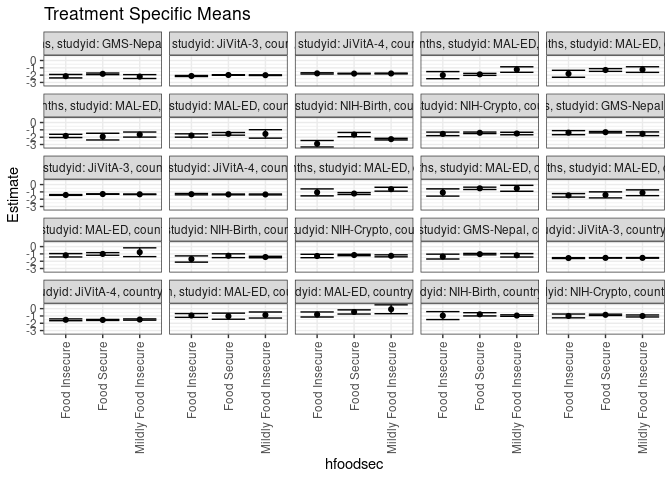

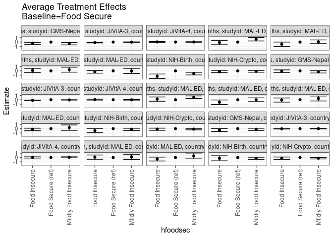

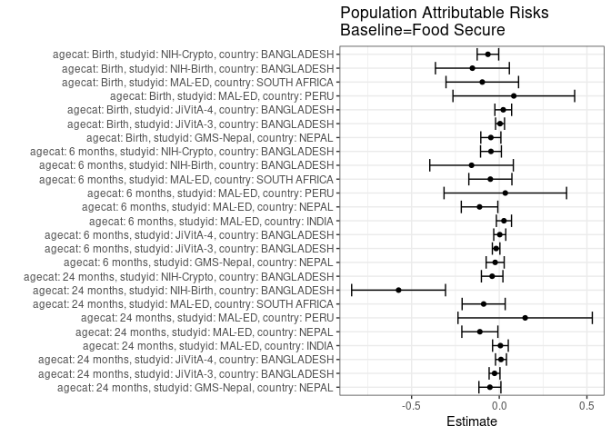

## Results Table

### Parameter: TSM

| agecat | studyid | country | intervention_level | baseline_level | estimate | ci_lower | ci_upper |
| --- | --- | --- | --- | --- | --- | --- | --- |
| Birth | GMS-Nepal | NEPAL | Food Secure | NA | -1.0312698 | -1.1273512 | -0.9351883 |
| Birth | GMS-Nepal | NEPAL | Mildly Food Insecure | NA | -1.1933506 | -1.4293878 | -0.9573135 |
| Birth | GMS-Nepal | NEPAL | Food Insecure | NA | -1.3665537 | -1.6965318 | -1.0365755 |
| Birth | JiVitA-3 | BANGLADESH | Food Secure | NA | -1.5420242 | -1.5746450 | -1.5094033 |
| Birth | JiVitA-3 | BANGLADESH | Mildly Food Insecure | NA | -1.5409570 | -1.5825696 | -1.4993445 |
| Birth | JiVitA-3 | BANGLADESH | Food Insecure | NA | -1.5689516 | -1.6252198 | -1.5126833 |
| Birth | JiVitA-4 | BANGLADESH | Food Secure | NA | -1.5476722 | -1.6157712 | -1.4795732 |
| Birth | JiVitA-4 | BANGLADESH | Mildly Food Insecure | NA | -1.4914518 | -1.5763428 | -1.4065608 |
| Birth | JiVitA-4 | BANGLADESH | Food Insecure | NA | -1.5260604 | -1.6488361 | -1.4032847 |
| Birth | MAL-ED | PERU | Food Secure | NA | -1.0319859 | -1.4493930 | -0.6145789 |
| Birth | MAL-ED | PERU | Mildly Food Insecure | NA | -0.8726837 | -1.2837213 | -0.4616461 |
| Birth | MAL-ED | PERU | Food Insecure | NA | -0.9373462 | -1.1968949 | -0.6777974 |
| Birth | MAL-ED | SOUTH AFRICA | Food Secure | NA | -0.4535556 | -0.7370575 | -0.1700536 |
| Birth | MAL-ED | SOUTH AFRICA | Mildly Food Insecure | NA | -0.0888889 | -0.6955550 | 0.5177773 |
| Birth | MAL-ED | SOUTH AFRICA | Food Insecure | NA | -0.8005882 | -1.1433809 | -0.4577955 |
| Birth | NIH-Birth | BANGLADESH | Food Secure | NA | -0.7777805 | -0.9985609 | -0.5570002 |
| Birth | NIH-Birth | BANGLADESH | Mildly Food Insecure | NA | -0.9457131 | -1.0461731 | -0.8452531 |
| Birth | NIH-Birth | BANGLADESH | Food Insecure | NA | -0.9544366 | -1.4955992 | -0.4132740 |
| Birth | NIH-Crypto | BANGLADESH | Food Secure | NA | -0.8449042 | -0.9342634 | -0.7555450 |
| Birth | NIH-Crypto | BANGLADESH | Mildly Food Insecure | NA | -1.0027687 | -1.1402181 | -0.8653193 |
| Birth | NIH-Crypto | BANGLADESH | Food Insecure | NA | -0.9977409 | -1.2596405 | -0.7358412 |
| 6 months | GMS-Nepal | NEPAL | Food Secure | NA | -1.3188363 | -1.4116375 | -1.2260351 |
| 6 months | GMS-Nepal | NEPAL | Mildly Food Insecure | NA | -1.5383736 | -1.7926942 | -1.2840529 |
| 6 months | GMS-Nepal | NEPAL | Food Insecure | NA | -1.3819866 | -1.6596162 | -1.1043569 |
| 6 months | JiVitA-3 | BANGLADESH | Food Secure | NA | -1.2952926 | -1.3262166 | -1.2643687 |
| 6 months | JiVitA-3 | BANGLADESH | Mildly Food Insecure | NA | -1.3262740 | -1.3613645 | -1.2911834 |
| 6 months | JiVitA-3 | BANGLADESH | Food Insecure | NA | -1.4196281 | -1.4739817 | -1.3652744 |
| 6 months | JiVitA-4 | BANGLADESH | Food Secure | NA | -1.3475307 | -1.3993783 | -1.2956831 |
| 6 months | JiVitA-4 | BANGLADESH | Mildly Food Insecure | NA | -1.3520195 | -1.4111896 | -1.2928493 |
| 6 months | JiVitA-4 | BANGLADESH | Food Insecure | NA | -1.3128409 | -1.4021711 | -1.2235107 |
| 6 months | MAL-ED | INDIA | Food Secure | NA | -1.2287544 | -1.3589893 | -1.0985195 |
| 6 months | MAL-ED | INDIA | Mildly Food Insecure | NA | -0.6360000 | -0.9019405 | -0.3700595 |
| 6 months | MAL-ED | INDIA | Food Insecure | NA | -1.0694118 | -1.5456747 | -0.5931488 |
| 6 months | MAL-ED | NEPAL | Food Secure | NA | -0.5139500 | -0.6740094 | -0.3538905 |
| 6 months | MAL-ED | NEPAL | Mildly Food Insecure | NA | -0.5108099 | -0.9172041 | -0.1044156 |
| 6 months | MAL-ED | NEPAL | Food Insecure | NA | -1.0833395 | -1.5783749 | -0.5883041 |
| 6 months | MAL-ED | PERU | Food Secure | NA | -1.4128460 | -1.8261285 | -0.9995635 |
| 6 months | MAL-ED | PERU | Mildly Food Insecure | NA | -1.1181977 | -1.5116610 | -0.7247344 |
| 6 months | MAL-ED | PERU | Food Insecure | NA | -1.4729433 | -1.7099960 | -1.2358906 |
| 6 months | MAL-ED | SOUTH AFRICA | Food Secure | NA | -1.0032473 | -1.1803645 | -0.8261302 |
| 6 months | MAL-ED | SOUTH AFRICA | Mildly Food Insecure | NA | -0.7699164 | -1.3737657 | -0.1660672 |
| 6 months | MAL-ED | SOUTH AFRICA | Food Insecure | NA | -1.1887990 | -1.4198531 | -0.9577449 |
| 6 months | NIH-Birth | BANGLADESH | Food Secure | NA | -1.2493998 | -1.5074260 | -0.9913735 |
| 6 months | NIH-Birth | BANGLADESH | Mildly Food Insecure | NA | -1.4259785 | -1.5230620 | -1.3288950 |
| 6 months | NIH-Birth | BANGLADESH | Food Insecure | NA | -1.6981244 | -2.1243588 | -1.2718900 |
| 6 months | NIH-Crypto | BANGLADESH | Food Secure | NA | -1.1513862 | -1.2438026 | -1.0589698 |
| 6 months | NIH-Crypto | BANGLADESH | Mildly Food Insecure | NA | -1.2610005 | -1.3967072 | -1.1252938 |
| 6 months | NIH-Crypto | BANGLADESH | Food Insecure | NA | -1.2858616 | -1.5201964 | -1.0515268 |
| 24 months | GMS-Nepal | NEPAL | Food Secure | NA | -1.8225682 | -1.9295177 | -1.7156187 |
| 24 months | GMS-Nepal | NEPAL | Mildly Food Insecure | NA | -2.1967425 | -2.4590743 | -1.9344108 |
| 24 months | GMS-Nepal | NEPAL | Food Insecure | NA | -2.1457633 | -2.3831156 | -1.9084110 |
| 24 months | JiVitA-3 | BANGLADESH | Food Secure | NA | -1.9831204 | -2.0251303 | -1.9411105 |
| 24 months | JiVitA-3 | BANGLADESH | Mildly Food Insecure | NA | -2.0062114 | -2.0530515 | -1.9593714 |
| 24 months | JiVitA-3 | BANGLADESH | Food Insecure | NA | -2.1171903 | -2.1810700 | -2.0533106 |
| 24 months | JiVitA-4 | BANGLADESH | Food Secure | NA | -1.7900251 | -1.8389786 | -1.7410716 |
| 24 months | JiVitA-4 | BANGLADESH | Mildly Food Insecure | NA | -1.7741735 | -1.8282894 | -1.7200576 |
| 24 months | JiVitA-4 | BANGLADESH | Food Insecure | NA | -1.7612583 | -1.8475472 | -1.6749694 |
| 24 months | MAL-ED | INDIA | Food Secure | NA | -1.8935000 | -2.0301943 | -1.7568057 |
| 24 months | MAL-ED | INDIA | Mildly Food Insecure | NA | -1.2370000 | -1.6132318 | -0.8607682 |
| 24 months | MAL-ED | INDIA | Food Insecure | NA | -2.0035294 | -2.4884028 | -1.5186561 |
| 24 months | MAL-ED | NEPAL | Food Secure | NA | -1.2986244 | -1.4835577 | -1.1136911 |
| 24 months | MAL-ED | NEPAL | Mildly Food Insecure | NA | -1.2400446 | -1.6241597 | -0.8559296 |
| 24 months | MAL-ED | NEPAL | Food Insecure | NA | -1.8142072 | -2.2907985 | -1.3376159 |
| 24 months | MAL-ED | PERU | Food Secure | NA | -1.9261256 | -2.3856207 | -1.4666305 |
| 24 months | MAL-ED | PERU | Mildly Food Insecure | NA | -1.6437872 | -1.9901947 | -1.2973798 |
| 24 months | MAL-ED | PERU | Food Insecure | NA | -1.8301497 | -2.0509673 | -1.6093320 |
| 24 months | MAL-ED | SOUTH AFRICA | Food Secure | NA | -1.5441350 | -1.7283086 | -1.3599614 |
| 24 months | MAL-ED | SOUTH AFRICA | Mildly Food Insecure | NA | -1.5561678 | -2.1329440 | -0.9793916 |
| 24 months | MAL-ED | SOUTH AFRICA | Food Insecure | NA | -1.7730453 | -2.0011681 | -1.5449224 |
| 24 months | NIH-Birth | BANGLADESH | Food Secure | NA | -1.6448422 | -1.9365860 | -1.3530983 |
| 24 months | NIH-Birth | BANGLADESH | Mildly Food Insecure | NA | -2.2701620 | -2.3793470 | -2.1609770 |
| 24 months | NIH-Birth | BANGLADESH | Food Insecure | NA | -2.8978267 | -3.3388989 | -2.4567545 |
| 24 months | NIH-Crypto | BANGLADESH | Food Secure | NA | -1.4007819 | -1.5050036 | -1.2965602 |
| 24 months | NIH-Crypto | BANGLADESH | Mildly Food Insecure | NA | -1.5001722 | -1.6702682 | -1.3300763 |
| 24 months | NIH-Crypto | BANGLADESH | Food Insecure | NA | -1.5501861 | -1.7951005 | -1.3052716 |

### Parameter: E(Y)

| agecat | studyid | country | intervention_level | baseline_level | estimate | ci_lower | ci_upper |
| --- | --- | --- | --- | --- | --- | --- | --- |
| Birth | GMS-Nepal | NEPAL | NA | NA | -1.0791964 | -1.1604792 | -0.9979137 |
| Birth | JiVitA-3 | BANGLADESH | NA | NA | -1.5375132 | -1.5596692 | -1.5153573 |
| Birth | JiVitA-4 | BANGLADESH | NA | NA | -1.5248719 | -1.5743851 | -1.4753587 |
| Birth | MAL-ED | PERU | NA | NA | -0.9490110 | -1.1400314 | -0.7579906 |
| Birth | MAL-ED | SOUTH AFRICA | NA | NA | -0.5503409 | -0.7616444 | -0.3390374 |
| Birth | NIH-Birth | BANGLADESH | NA | NA | -0.9310197 | -1.0197391 | -0.8423003 |
| Birth | NIH-Crypto | BANGLADESH | NA | NA | -0.9094945 | -0.9809370 | -0.8380521 |
| 6 months | GMS-Nepal | NEPAL | NA | NA | -1.3421764 | -1.4201083 | -1.2642445 |
| 6 months | JiVitA-3 | BANGLADESH | NA | NA | -1.3131326 | -1.3362851 | -1.2899801 |
| 6 months | JiVitA-4 | BANGLADESH | NA | NA | -1.3446891 | -1.3822219 | -1.3071564 |
| 6 months | MAL-ED | INDIA | NA | NA | -1.2019969 | -1.3256948 | -1.0782989 |
| 6 months | MAL-ED | NEPAL | NA | NA | -0.6262760 | -0.7758267 | -0.4767254 |
| 6 months | MAL-ED | PERU | NA | NA | -1.3783784 | -1.5611768 | -1.1955799 |
| 6 months | MAL-ED | SOUTH AFRICA | NA | NA | -1.0539254 | -1.1902766 | -0.9175743 |
| 6 months | NIH-Birth | BANGLADESH | NA | NA | -1.4073821 | -1.4960598 | -1.3187043 |
| 6 months | NIH-Crypto | BANGLADESH | NA | NA | -1.1986783 | -1.2700937 | -1.1272630 |
| 24 months | GMS-Nepal | NEPAL | NA | NA | -1.8758368 | -1.9623349 | -1.7893388 |
| 24 months | JiVitA-3 | BANGLADESH | NA | NA | -2.0099416 | -2.0377955 | -1.9820876 |
| 24 months | JiVitA-4 | BANGLADESH | NA | NA | -1.7801485 | -1.8158427 | -1.7444543 |
| 24 months | MAL-ED | INDIA | NA | NA | -1.8868396 | -2.0164954 | -1.7571839 |
| 24 months | MAL-ED | NEPAL | NA | NA | -1.4092187 | -1.5701249 | -1.2483126 |
| 24 months | MAL-ED | PERU | NA | NA | -1.7783956 | -1.9536701 | -1.6031212 |
| 24 months | MAL-ED | SOUTH AFRICA | NA | NA | -1.6331323 | -1.7704624 | -1.4958022 |
| 24 months | NIH-Birth | BANGLADESH | NA | NA | -2.2190579 | -2.3217459 | -2.1163699 |
| 24 months | NIH-Crypto | BANGLADESH | NA | NA | -1.4412646 | -1.5249156 | -1.3576135 |

### Parameter: ATE

| agecat | studyid | country | intervention_level | baseline_level | estimate | ci_lower | ci_upper |
| --- | --- | --- | --- | --- | --- | --- | --- |
| Birth | GMS-Nepal | NEPAL | Food Secure | Food Secure | 0.0000000 | 0.0000000 | 0.0000000 |
| Birth | GMS-Nepal | NEPAL | Mildly Food Insecure | Food Secure | -0.1620808 | -0.4172751 | 0.0931134 |
| Birth | GMS-Nepal | NEPAL | Food Insecure | Food Secure | -0.3352839 | -0.6791167 | 0.0085489 |
| Birth | JiVitA-3 | BANGLADESH | Food Secure | Food Secure | 0.0000000 | 0.0000000 | 0.0000000 |
| Birth | JiVitA-3 | BANGLADESH | Mildly Food Insecure | Food Secure | 0.0010671 | -0.0506105 | 0.0527447 |
| Birth | JiVitA-3 | BANGLADESH | Food Insecure | Food Secure | -0.0269274 | -0.0915182 | 0.0376634 |
| Birth | JiVitA-4 | BANGLADESH | Food Secure | Food Secure | 0.0000000 | 0.0000000 | 0.0000000 |
| Birth | JiVitA-4 | BANGLADESH | Mildly Food Insecure | Food Secure | 0.0562204 | -0.0509110 | 0.1633518 |
| Birth | JiVitA-4 | BANGLADESH | Food Insecure | Food Secure | 0.0216118 | -0.1192944 | 0.1625181 |
| Birth | MAL-ED | PERU | Food Secure | Food Secure | 0.0000000 | 0.0000000 | 0.0000000 |
| Birth | MAL-ED | PERU | Mildly Food Insecure | Food Secure | 0.1593022 | -0.4269840 | 0.7455884 |
| Birth | MAL-ED | PERU | Food Insecure | Food Secure | 0.0946398 | -0.3987377 | 0.5880172 |
| Birth | MAL-ED | SOUTH AFRICA | Food Secure | Food Secure | 0.0000000 | 0.0000000 | 0.0000000 |
| Birth | MAL-ED | SOUTH AFRICA | Mildly Food Insecure | Food Secure | 0.3646667 | -0.3049729 | 1.0343063 |
| Birth | MAL-ED | SOUTH AFRICA | Food Insecure | Food Secure | -0.3470327 | -0.7918699 | 0.0978046 |
| Birth | NIH-Birth | BANGLADESH | Food Secure | Food Secure | 0.0000000 | 0.0000000 | 0.0000000 |
| Birth | NIH-Birth | BANGLADESH | Mildly Food Insecure | Food Secure | -0.1679325 | -0.4113799 | 0.0755149 |
| Birth | NIH-Birth | BANGLADESH | Food Insecure | Food Secure | -0.1766561 | -0.7625189 | 0.4092068 |
| Birth | NIH-Crypto | BANGLADESH | Food Secure | Food Secure | 0.0000000 | 0.0000000 | 0.0000000 |
| Birth | NIH-Crypto | BANGLADESH | Mildly Food Insecure | Food Secure | -0.1578645 | -0.3219875 | 0.0062585 |
| Birth | NIH-Crypto | BANGLADESH | Food Insecure | Food Secure | -0.1528367 | -0.4294841 | 0.1238108 |
| 6 months | GMS-Nepal | NEPAL | Food Secure | Food Secure | 0.0000000 | 0.0000000 | 0.0000000 |
| 6 months | GMS-Nepal | NEPAL | Mildly Food Insecure | Food Secure | -0.2195373 | -0.4904545 | 0.0513799 |
| 6 months | GMS-Nepal | NEPAL | Food Insecure | Food Secure | -0.0631503 | -0.3559593 | 0.2296588 |
| 6 months | JiVitA-3 | BANGLADESH | Food Secure | Food Secure | 0.0000000 | 0.0000000 | 0.0000000 |
| 6 months | JiVitA-3 | BANGLADESH | Mildly Food Insecure | Food Secure | -0.0309813 | -0.0723425 | 0.0103799 |
| 6 months | JiVitA-3 | BANGLADESH | Food Insecure | Food Secure | -0.1243354 | -0.1838879 | -0.0647830 |
| 6 months | JiVitA-4 | BANGLADESH | Food Secure | Food Secure | 0.0000000 | 0.0000000 | 0.0000000 |
| 6 months | JiVitA-4 | BANGLADESH | Mildly Food Insecure | Food Secure | -0.0044888 | -0.0799098 | 0.0709323 |
| 6 months | JiVitA-4 | BANGLADESH | Food Insecure | Food Secure | 0.0346898 | -0.0683570 | 0.1377366 |
| 6 months | MAL-ED | INDIA | Food Secure | Food Secure | 0.0000000 | 0.0000000 | 0.0000000 |
| 6 months | MAL-ED | INDIA | Mildly Food Insecure | Food Secure | 0.5927544 | 0.2966371 | 0.8888717 |
| 6 months | MAL-ED | INDIA | Food Insecure | Food Secure | 0.1593426 | -0.3344058 | 0.6530910 |
| 6 months | MAL-ED | NEPAL | Food Secure | Food Secure | 0.0000000 | 0.0000000 | 0.0000000 |
| 6 months | MAL-ED | NEPAL | Mildly Food Insecure | Food Secure | 0.0031401 | -0.4347760 | 0.4410562 |
| 6 months | MAL-ED | NEPAL | Food Insecure | Food Secure | -0.5693896 | -1.0897719 | -0.0490073 |
| 6 months | MAL-ED | PERU | Food Secure | Food Secure | 0.0000000 | 0.0000000 | 0.0000000 |
| 6 months | MAL-ED | PERU | Mildly Food Insecure | Food Secure | 0.2946483 | -0.2727839 | 0.8620805 |
| 6 months | MAL-ED | PERU | Food Insecure | Food Secure | -0.0600973 | -0.5349313 | 0.4147366 |
| 6 months | MAL-ED | SOUTH AFRICA | Food Secure | Food Secure | 0.0000000 | 0.0000000 | 0.0000000 |
| 6 months | MAL-ED | SOUTH AFRICA | Mildly Food Insecure | Food Secure | 0.2333309 | -0.3964119 | 0.8630737 |
| 6 months | MAL-ED | SOUTH AFRICA | Food Insecure | Food Secure | -0.1855517 | -0.4769157 | 0.1058123 |
| 6 months | NIH-Birth | BANGLADESH | Food Secure | Food Secure | 0.0000000 | 0.0000000 | 0.0000000 |
| 6 months | NIH-Birth | BANGLADESH | Mildly Food Insecure | Food Secure | -0.1765787 | -0.4519450 | 0.0987875 |
| 6 months | NIH-Birth | BANGLADESH | Food Insecure | Food Secure | -0.4487247 | -0.9470962 | 0.0496469 |
| 6 months | NIH-Crypto | BANGLADESH | Food Secure | Food Secure | 0.0000000 | 0.0000000 | 0.0000000 |
| 6 months | NIH-Crypto | BANGLADESH | Mildly Food Insecure | Food Secure | -0.1096143 | -0.2735517 | 0.0543231 |
| 6 months | NIH-Crypto | BANGLADESH | Food Insecure | Food Secure | -0.1344754 | -0.3859423 | 0.1169915 |
| 24 months | GMS-Nepal | NEPAL | Food Secure | Food Secure | 0.0000000 | 0.0000000 | 0.0000000 |
| 24 months | GMS-Nepal | NEPAL | Mildly Food Insecure | Food Secure | -0.3741743 | -0.6585631 | -0.0897856 |
| 24 months | GMS-Nepal | NEPAL | Food Insecure | Food Secure | -0.3231951 | -0.5838678 | -0.0625223 |
| 24 months | JiVitA-3 | BANGLADESH | Food Secure | Food Secure | 0.0000000 | 0.0000000 | 0.0000000 |
| 24 months | JiVitA-3 | BANGLADESH | Mildly Food Insecure | Food Secure | -0.0230910 | -0.0828764 | 0.0366944 |
| 24 months | JiVitA-3 | BANGLADESH | Food Insecure | Food Secure | -0.1340699 | -0.2042550 | -0.0638848 |
| 24 months | JiVitA-4 | BANGLADESH | Food Secure | Food Secure | 0.0000000 | 0.0000000 | 0.0000000 |
| 24 months | JiVitA-4 | BANGLADESH | Mildly Food Insecure | Food Secure | 0.0158516 | -0.0532222 | 0.0849255 |
| 24 months | JiVitA-4 | BANGLADESH | Food Insecure | Food Secure | 0.0287668 | -0.0679650 | 0.1254987 |
| 24 months | MAL-ED | INDIA | Food Secure | Food Secure | 0.0000000 | 0.0000000 | 0.0000000 |
| 24 months | MAL-ED | INDIA | Mildly Food Insecure | Food Secure | 0.6565000 | 0.2562055 | 1.0567945 |
| 24 months | MAL-ED | INDIA | Food Insecure | Food Secure | -0.1100294 | -0.6138027 | 0.3937438 |
| 24 months | MAL-ED | NEPAL | Food Secure | Food Secure | 0.0000000 | 0.0000000 | 0.0000000 |
| 24 months | MAL-ED | NEPAL | Mildly Food Insecure | Food Secure | 0.0585798 | -0.3694728 | 0.4866323 |
| 24 months | MAL-ED | NEPAL | Food Insecure | Food Secure | -0.5155828 | -1.0268621 | -0.0043035 |
| 24 months | MAL-ED | PERU | Food Secure | Food Secure | 0.0000000 | 0.0000000 | 0.0000000 |
| 24 months | MAL-ED | PERU | Mildly Food Insecure | Food Secure | 0.2823384 | -0.2949588 | 0.8596356 |
| 24 months | MAL-ED | PERU | Food Insecure | Food Secure | 0.0959760 | -0.4104525 | 0.6024045 |
| 24 months | MAL-ED | SOUTH AFRICA | Food Secure | Food Secure | 0.0000000 | 0.0000000 | 0.0000000 |
| 24 months | MAL-ED | SOUTH AFRICA | Mildly Food Insecure | Food Secure | -0.0120328 | -0.6176289 | 0.5935633 |
| 24 months | MAL-ED | SOUTH AFRICA | Food Insecure | Food Secure | -0.2289102 | -0.5237652 | 0.0659448 |
| 24 months | NIH-Birth | BANGLADESH | Food Secure | Food Secure | 0.0000000 | 0.0000000 | 0.0000000 |
| 24 months | NIH-Birth | BANGLADESH | Mildly Food Insecure | Food Secure | -0.6253198 | -0.9371504 | -0.3134892 |
| 24 months | NIH-Birth | BANGLADESH | Food Insecure | Food Secure | -1.2529846 | -1.7822461 | -0.7237230 |
| 24 months | NIH-Crypto | BANGLADESH | Food Secure | Food Secure | 0.0000000 | 0.0000000 | 0.0000000 |
| 24 months | NIH-Crypto | BANGLADESH | Mildly Food Insecure | Food Secure | -0.0993903 | -0.2989426 | 0.1001620 |
| 24 months | NIH-Crypto | BANGLADESH | Food Insecure | Food Secure | -0.1494041 | -0.4155927 | 0.1167844 |

### Parameter: PAR

| agecat | studyid | country | intervention_level | baseline_level | estimate | ci_lower | ci_upper |
| --- | --- | --- | --- | --- | --- | --- | --- |
| Birth | GMS-Nepal | NEPAL | Food Secure | NA | -0.0479267 | -0.1052405 | 0.0093872 |
| Birth | JiVitA-3 | BANGLADESH | Food Secure | NA | 0.0045109 | -0.0210248 | 0.0300467 |
| Birth | JiVitA-4 | BANGLADESH | Food Secure | NA | 0.0228003 | -0.0250023 | 0.0706030 |
| Birth | MAL-ED | PERU | Food Secure | NA | 0.0829749 | -0.2641000 | 0.4300499 |
| Birth | MAL-ED | SOUTH AFRICA | Food Secure | NA | -0.0967854 | -0.3037214 | 0.1101506 |
| Birth | NIH-Birth | BANGLADESH | Food Secure | NA | -0.1532392 | -0.3640558 | 0.0575774 |
| Birth | NIH-Crypto | BANGLADESH | Food Secure | NA | -0.0645903 | -0.1260170 | -0.0031637 |
| 6 months | GMS-Nepal | NEPAL | Food Secure | NA | -0.0233401 | -0.0748143 | 0.0281340 |
| 6 months | JiVitA-3 | BANGLADESH | Food Secure | NA | -0.0178400 | -0.0393850 | 0.0037050 |
| 6 months | JiVitA-4 | BANGLADESH | Food Secure | NA | 0.0028416 | -0.0314445 | 0.0371276 |
| 6 months | MAL-ED | INDIA | Food Secure | NA | 0.0267575 | -0.0163737 | 0.0698887 |
| 6 months | MAL-ED | NEPAL | Food Secure | NA | -0.1123261 | -0.2164703 | -0.0081819 |
| 6 months | MAL-ED | PERU | Food Secure | NA | 0.0344676 | -0.3149427 | 0.3838779 |
| 6 months | MAL-ED | SOUTH AFRICA | Food Secure | NA | -0.0506781 | -0.1735202 | 0.0721640 |
| 6 months | NIH-Birth | BANGLADESH | Food Secure | NA | -0.1579823 | -0.3962354 | 0.0802708 |
| 6 months | NIH-Crypto | BANGLADESH | Food Secure | NA | -0.0472921 | -0.1067123 | 0.0121281 |
| 24 months | GMS-Nepal | NEPAL | Food Secure | NA | -0.0532686 | -0.1160200 | 0.0094828 |
| 24 months | JiVitA-3 | BANGLADESH | Food Secure | NA | -0.0268211 | -0.0577646 | 0.0041223 |
| 24 months | JiVitA-4 | BANGLADESH | Food Secure | NA | 0.0098766 | -0.0213323 | 0.0410855 |
| 24 months | MAL-ED | INDIA | Food Secure | NA | 0.0066604 | -0.0380987 | 0.0514195 |
| 24 months | MAL-ED | NEPAL | Food Secure | NA | -0.1105944 | -0.2133963 | -0.0077924 |
| 24 months | MAL-ED | PERU | Food Secure | NA | 0.1477300 | -0.2353443 | 0.5308043 |
| 24 months | MAL-ED | SOUTH AFRICA | Food Secure | NA | -0.0889973 | -0.2118173 | 0.0338227 |
| 24 months | NIH-Birth | BANGLADESH | Food Secure | NA | -0.5742157 | -0.8418757 | -0.3065558 |
| 24 months | NIH-Crypto | BANGLADESH | Food Secure | NA | -0.0404827 | -0.1018558 | 0.0208905 |